# Zadanie zaliczeniowe 1

Wojciech Kłopotek

29 04 2021

# Treść zadania

**Celem** zadania jest staystyczna analiza danych znajdujących się w pliku `people.tab`.

**Dane:** Są to dane symulowane; opisują wiek (zmienna `age`), wagę (`weight`), wzrost (`height`), płeć (`gender`), stan cywilny (`married`), liczbę dzieci (`number_of_kids`), posiadane zwierzę domowe (`pet`) oraz miesięczne wydatki (`expenses`) pewnych osób. We wszystkich zadaniach poniżej zmienna `expenses` jest **zmienną objaśnianą** (zależną), a pozostałe zmienne są **zmiennymi objaśniającymi** (niezależnymi).

**Wynikiem** ma być raport w formacie .Rmd oraz skompilowany do html. Raport w obydwu formatach należy przesłać na adres email do prwoadzącego laboratorium do sprawdzenia.

# Zadanie 1

*Wczytaj dane, objerzyj je i podsumuj w dwóch-trzech zdaniach. Pytania pomocnicze: ile jest obserwacji, ile zmiennych ilościowych, a ile jakościowych? Czy są zależności w zmiennych objaśniających (policz i zaprezentuj na wykresach korelacje pomiędzy zmiennymi ilościowymi), a także zbadaj zależność zmiennych jakościowych. Skomentuj wyniki. Czy występują jakieś braki danych?*

```r
df <- read.csv("people.tab", sep="\t")
```

Zbiór danych zawiera 501 obserwacji, 3 zmienne jakościowe i 5 zmiennych ilościowych.

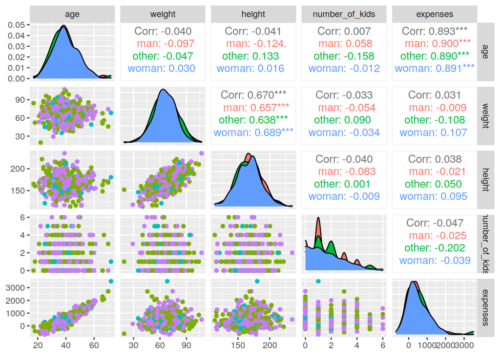

```r
library(ggplot2)
library(GGally)
ggpairs(df, aes(col=gender), columns = c(1,2,3,6,8))
```

Widzimy statystycznie znaczące korelacje między zmiennymi `expenses` i `age` (wydatkami a wiekiem) oraz `height` i `weight` (wzrostem i wagą) dla zagregowanych danych oraz dla wszystkich płci osobno.

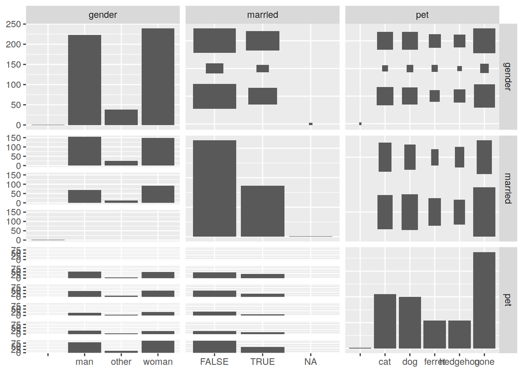

```r
ggpairs(df[,c(4,5,7)])
```

Z powyższego wynika między innymi, że osoby będące w związku małżeńskim mają średnio mniej zwierząt od osób nie żyjących w małżeństwach.

W danych występują pojedyncze braki:

```r
colSums(is.na(df))
```

```
##            age         weight         height         gender        married
##              1              1              1              0              1
## number_of_kids            pet       expenses
##              1              0              1
```

Konkretnie zbiór danych zawiera 1 wybrakowanych wierszy. Usunę je

```r
df = df[-which(rowSums(is.na(df)) > 0),]
```

# Zadanie 2

**Podsumuj dane przynajmniej trzema różnymi wykresami**. Należy przygotować:

- *wykres typu scatter-plot (taki jak na wykładzie 6, slajd 3) dla wszystkich zmiennych objaśniających ilościowych i zmiennej objaśnianej*
- *Wykresy typu pudełkowy (boxplot) dla jednej wybranej zmiennej ilościowej.*
- *Wykres typu słupkowy (barplot) dla jednej wybranej zmiennej jakościowej.*

*Mile widziane dodatkowe wykresy wg własnej inwencji (np. histogram, punktowy, liniowy, mapa ciepła, …)*

## Wykres typu scatter-plot

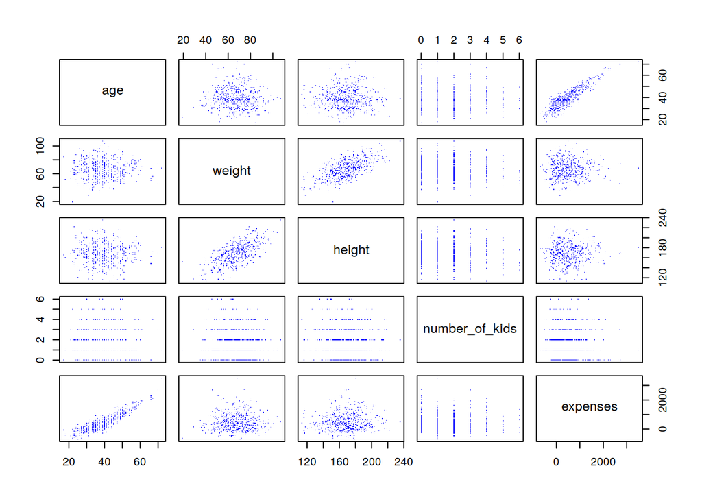

```r
pairs(~ age + weight + height + number_of_kids + expenses, data = df, col = 'blue', pch='.')
```

## Wykres typu box-plot dla zmiennej ilościowej

Wykres przybliżający rozkład wieku.

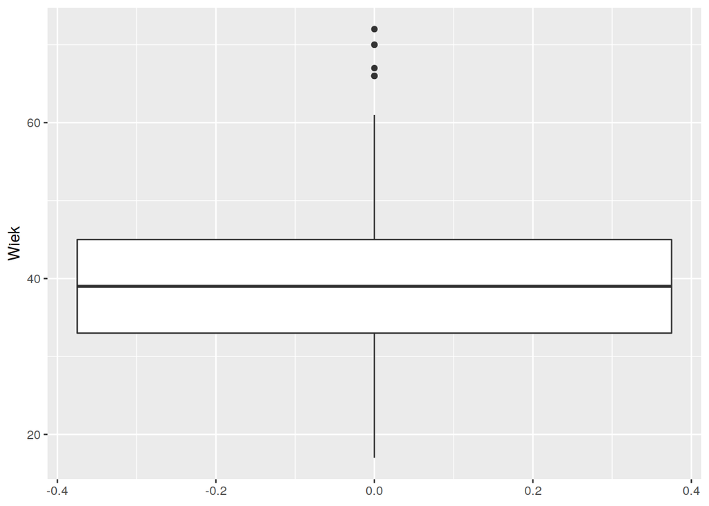

```r
library(ggplot2)

ggplot(df) + geom_boxplot(aes(y = age)) + labs(y="Wiek")
```

## Wykres typu słupkowy dla zmiennej jakościowej

Wykres przedstawiający liczby poszczególnych zwierząt

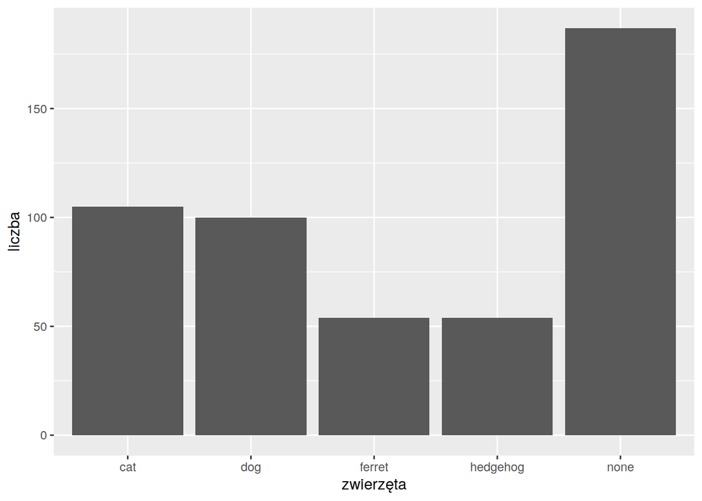

```r
# Usuwamy niepoprawny wiersz
ggplot(df) + geom_bar(aes(x = pet)) + labs(x="zwierzęta", y="liczba")
```

## Mapa ciepła

Mapa ciepła pokazująca zależność wydatków w zależności od wzrostu i wagi

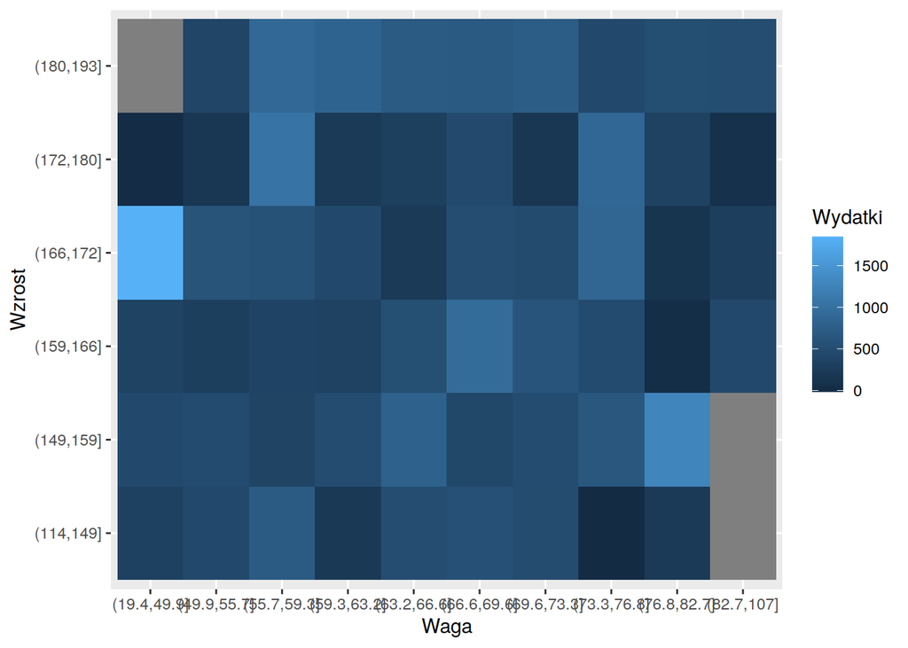

```r
by_stop = 0.15
weight_cuts <- cut(df$weight, quantile(df$weight, probs=seq(0, 1, 0.1)))
height_cuts <- cut(df$height, quantile(df$height, probs=seq(0, 1, by_stop)))
wh.grid <- expand.grid(X=levels(weight_cuts), Y=levels(height_cuts))

wh.grid$Z <- apply(wh.grid, 1, function(col) mean(df$expenses[which(weight_cuts == col[1] & height_cuts == col[2])]))
ggplot(wh.grid, aes(x=X, y=Y, fill=Z)) + geom_tile() + xlab("Waga") + ylab("Wzrost") + labs(fill="Wydatki")
```

# Zadanie 3

**Policz p-wartości dla hipotez o wartości średniej $m = 170$ i medianie $me = 165$ (cm)** dla zmiennej $wzrost$. Wybierz statystykę testową dla alternatywy lewostronnej, podaj założenia, z jakich korzystałeś i skomentuj, czy wydają Ci się uprawnione

Założę, że średnia zmiennej $wzrost$ ma rozkład normalny, ze względu na to, że jest duża liczba obserwacji (500 > 30), są one niezależne i pochodzą one z tego samego rozkładu, więc możemy użyć Centralnego Twierdzenia Granicznego. Ze względu na to, że nie znamy wariancji populacji, ale liczność próby jest liczna ($n = $500) użyję wariancji próby i policzę statystykę testową dla standardowego rozkładu normalnego:

$$Z = \frac{\bar{X} - m}{S_n}\sqrt{n} \sim U$$

```r
m <- 170
n <- nrow(df)
S_n <- sd(df$height)
Z <- (mean(df$height) - m) / S_n * sqrt(n)
pnorm(Z)
```

```
## [1] 0.01923004
```

Jeśli założymy, że $wzrost$ ma rozkład normalny, możemy skorzystać z testu istotności dla średniej przy nieznanej wariancji i wtedy $Z = \frac{\bar{X}-m}{S_n}\sqrt{n-1} \sim T$, gdzie tym razem $S_n$ to obciążony estymator odchylenia standardowego. Wartość p wychodzi niewiele większa.

```r
m <- 170
n <- nrow(df)
# Musimy użyć obciążonego estymatora odchylenia standardowego
S_n <- sqrt((n-1)/n)*sd(df$height)
Z <- (mean(df$height) - m) / S_n * sqrt(n-1)
pt(Z, df=n-1)
```

```
## [1] 0.01948702
```

Dla mediany możemy przeprowadzić test Wilcoxona dla jednej próby

```r
wilcox.test(df$height, mu=165, alternative="less")
```

```
##
##  Wilcoxon signed rank test with continuity correction
##
## data:  df$height
## V = 74416, p-value = 0.9999
## alternative hypothesis: true location is less than 165
```

# Zadanie 4

**Policz dwustronne przedziały ufności** na poziomie $0.99$ dla zmiennej $wiek$ dla następujących parametrów rozkładu: 1. *średnia i odchylenie standardowe* 2. *kwantyle $\frac{1}{4}$, $\frac{2}{4}$ i $\frac{3}{4}$* *Podaj założenia, z jakich korzystałeś i skomentuj, czy wydają Ci się uprawnione.*

Z wykresu Q-Q plot dla zmiennej $wiek$ wynika, że ma ona rozkład w przybliżeniu normalny. (Wykres jest liniowy)

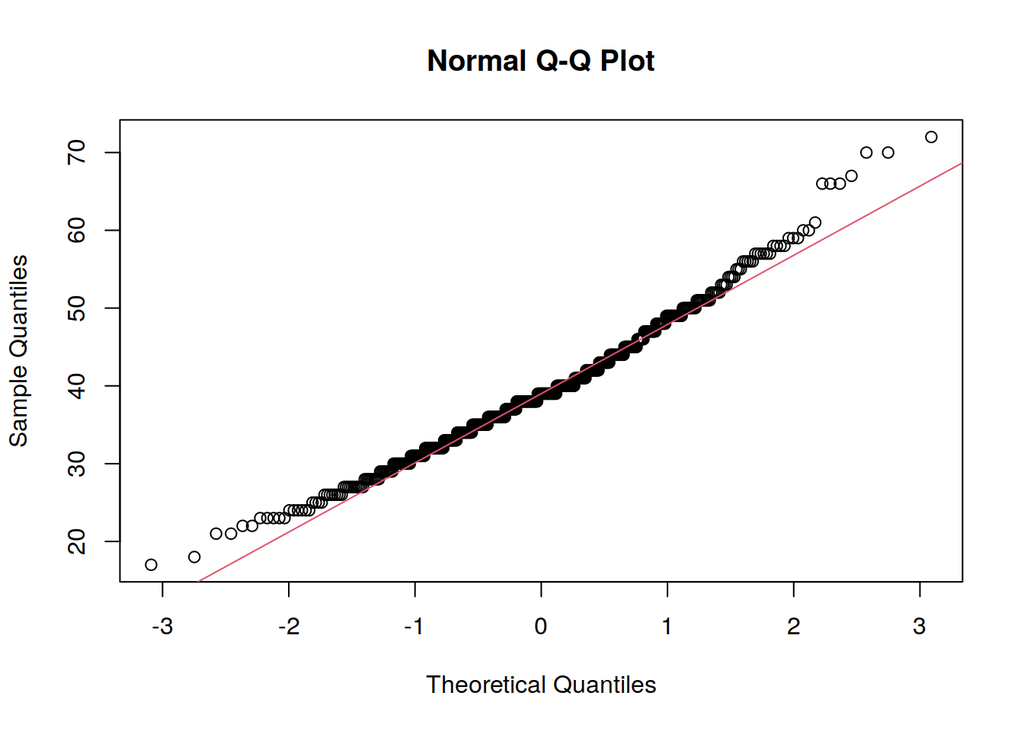

```r
# df.woman <- df$gender == "woman"
# df.man <- df$gender == "man"
qqnorm(df$age); qqline(df$age, col=2)
```

## Przedziały ufności dla średniej

Jeśli $P\left(\frac{\bar{X}-\mu}{S_n}\sqrt{n} \in (\pm z_{0.995})\right) = 0.99$, to: $P\left(\mu \in (\bar{X} \mp \frac{S_n}{\sqrt{n}}z_{0.995})\right) = 0.99$. Korzystamy z Centralnego Twierdzenia Granicznego (jak w poprzednim punkcie, korzystam z nieobciążonego estymatora odchylenia standardowego).

```r
n <- nrow(df)
S_n <- sd(df$age)

show(c(mean(df$age) - S_n / sqrt(n) * qnorm(0.995), mean(df$age) + S_n / sqrt(n) * qnorm(0.995)))
```

```
## [1] 38.44997 40.51803
```

## Przedziały ufności dla odchylenia standardowego

Zakładając, że obserwacje wieku są niezależne, możemy zauważyć, że $P \left( \frac{nS_n^2}{\sigma^2} \in (\chi^2(0.005,n-1), \chi^2(0.995,n-1))\right) = 0.99$, więc: $P \left( \sigma^2 \in \left( \frac{nS_n^2}{\chi^2(0.995,n-1)}, \frac{nS_n^2}{\chi^2(0.005,n-1)} \right) \right) = 0.99$

```r
n <- nrow(df)
S2 <- (n-1) / n * var(df$age)

show(c( sqrt(n*S2 / qchisq(0.995, n-1)), sqrt(n*S2 / qchisq(0.005, n-1)) ))
```

```
## [1] 8.296544 9.768113
```

## Kwartyle

Aby oszacować przedziały ufności poszczególnych kwantyli, wykorzystam metodę Bootstrap. Wezmę $B=1000$ repróbek.

```r
quartile.first <- replicate(1000, quantile(sample(df$age, 500, rep=T), 0.25))
quartile.second <- replicate(1000, quantile(sample(df$age, 500, rep=T), 0.5))
quartile.third <- replicate(1000, quantile(sample(df$age, 500, rep=T), 0.75))
quartiles <- matrix(c(quartile.first, quartile.second, quartile.third), ncol=3)
show(apply(quartiles, 2, mean))
```

```
## [1] 33.44625 38.72150 44.69950
```

Powyżej widzimy średnie kwartyle. Teraz policzmy przedziały ufności:

```r
apply(quartiles, 2, function(x) quantile(x, c(0.005, 0.995)))
```

```
##       [,1] [,2] [,3]
## 0.5%    32   38   43
## 99.5%   35   40   47
```

# Zadanie 5

*Przetestuj na poziomie istotności $0.01$ trzy hipotezy istotności:* 1. *różnicy między średnią wartością wybranej zmiennej dla kobiet i dla mężczyzn* 2. *zależności między dwiema zmiennymi ilościowymi* 3. *zależności między dwiema zmiennymi jakościowymi*

## Różnica między średnią wartością wzrostu dla kobiet i dla mężczyzn

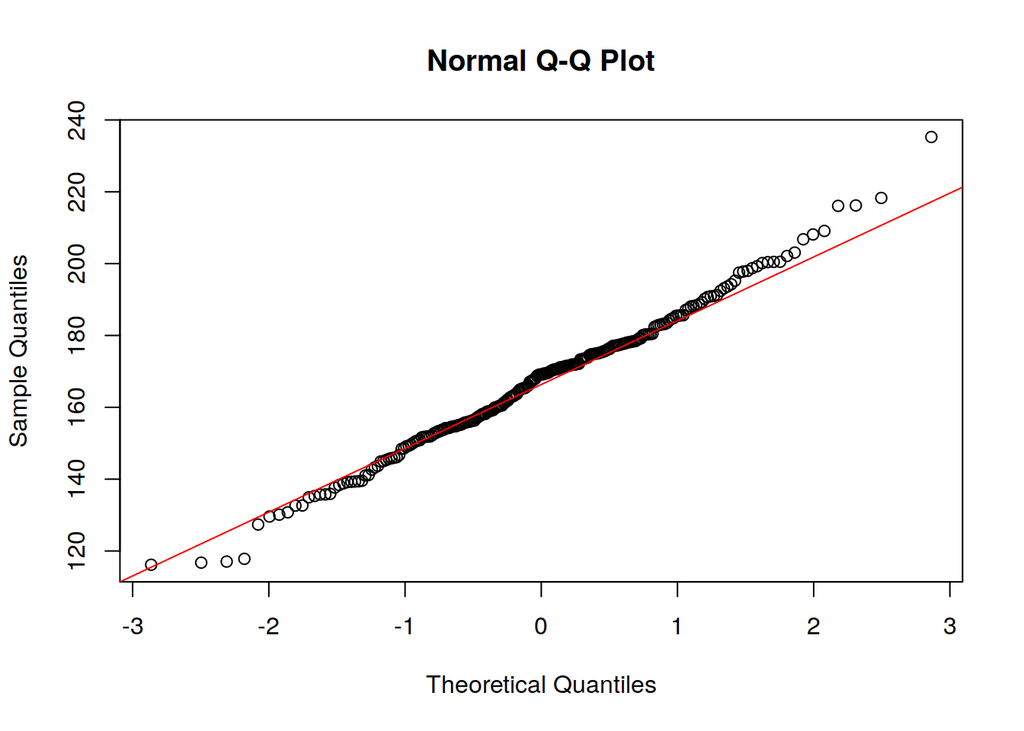

```r
df.woman <- df$gender == "woman"
df.man <- df$gender == "man"
qqnorm(df[df.woman,]$height); qqline(df[df.woman,]$height, col='red')
```

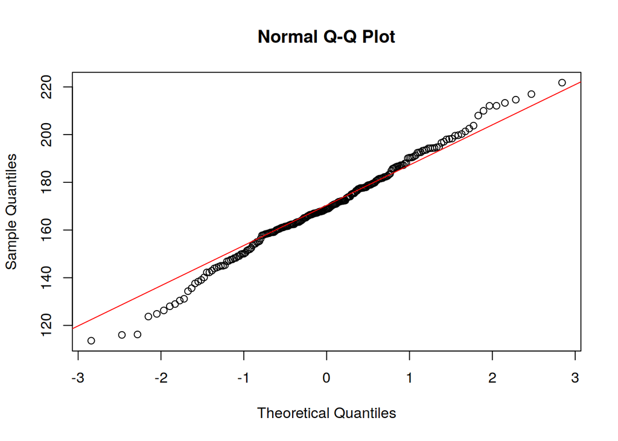

```r
qqnorm(df[df.man,]$height); qqline(df[df.man,]$height, col='red')
```

Wykresy wyglądają na leżące na prostej, więc uznam, że obie zmienne pochodzą z rozkładu normalnego (a przynajmniej tak je przybliżę).

Skorzystamy z t-testu dla dwóch średnich (testu Welcha). Przyjmujemy przy tym hipotezy:
$$H_0: \mu_1 = \mu_2 \\
H_a: \mu_1 \not= \mu_2$$
Użyjemy statystyki testowej o rokzładzie
$$T = \frac{\bar{X_1} - \bar{X_2}}{\sqrt{\frac{s_1^2}{N_1} + \frac{s_2^2}{N_2}}}$$

```r
t.test(df[df.woman,]$height, df[df.man,]$height, alternative="two.sided", var.equal=F, conf.level=0.99)
```

```
##
##  Welch Two Sample t-test
##
## data:  df[df.woman, ]$height and df[df.man, ]$height
## t = -1.3099, df = 457.54, p-value = 0.1909
## alternative hypothesis: true difference in means is not equal to 0
## 99 percent confidence interval:
##  -7.171254  2.349716
## sample estimates:
## mean of x mean of y
##  167.1913  169.6021
```

Z powyższego wynika, że dla przyjętego poziomu istotności nie możemy odrzucić hipotezy zerowej, więc przyjmujemy, że kobiety i mężczyźni mają średnio tyle samo wzrostu.

## Zależność między wzrostem a wagą

Za pomocą testu niezależności $\rho$-Spearmana, czy wzrost i waga są niezależne. Hipotezy:
$$H_0: height \text{ i } weight \text{ są niezależne} \\
H_1: \text{istnieje zależność między } height \text{ i } weight\\$$

```r
cor.test(df$height, df$weight, method="spearman", conf.level = 0.99)
```

```
##
##  Spearman's rank correlation rho
##
## data:  df$height and df$weight
## S = 7431066, p-value < 2.2e-16
## alternative hypothesis: true rho is not equal to 0
## sample estimates:
##       rho
## 0.6433074
```

p-wartość w powyższej funkcji została policzona korzystając z wartości rozkładu t. Tak czy siak, wartość p dla naszego modelu jest znacznie mniejsza niż wymagany przez nas poziom istotności, więc odrzucamy hipotezę zerową i mówimy, że istnieje zależność między wzrostem i wagą.

## Zależność między płcią a statusem małżeńskim

Tym razem wykorzystamy test $\chi^2$-Pearsona. Przyjmując oznaczenia brzegowych rozkładów: $P(X=x_i)=p_{i.}, P(Y=y_j)=p_{.j}$ oraz łącznego rozkładu $P(X=x_i,Y=y_j)=p_{ij}$ (gdzie $X$ uznajmy, że jest płcią, $Y$ statusem małżeńskim), badamy następujące hipotezy:
$$H_0: p_{ij} = p_{i.}p_{.j} \\
H_1: p_{ij} \not= p_{i.}p_{.j} \text{ (zmienne zależne)}$$

```r
test.table <- table(df$gender, df$married)
show(test.table)
```

```
##
##         FALSE TRUE
##   man     154   69
##   other    25   13
##   woman   148   91
```

```r
chisq.test(test.table)
```

```
##
##  Pearson's Chi-squared test
##
## data:  test.table
## X-squared = 2.5971, df = 2, p-value = 0.2729
```

Widzimy, że uzyskane p-value jest wyższe niż oczekiwany od nas poziom istotności, więc nie odrzucamy hipotezy zerowej i uznajemy, że płeć i status małżeński są niezależne.

## Test zgodności rozkładu wzrostu

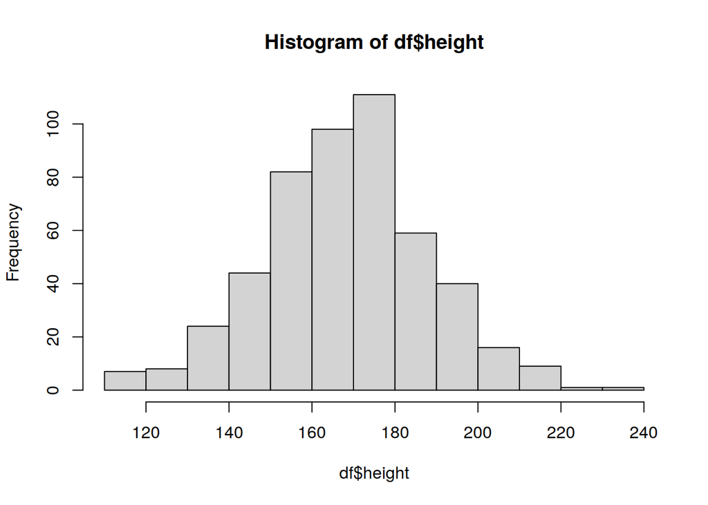

```r
hist(df$height)
```

Histogram zmiennej ma “cięższy” lewy ogon (Podejrzewam, że ma to związek z tym, że po wieku dojrzewania człowiek niewiele rośnie, a w starości w zasadzie ich wzrost się zmniejsza). Spróbowałem znaleźć parametry rozkładu logarytmicznie normalnego, dla których ten rozkład najbliżej oddaje rozkład wzrostu:

```r
library(MASS)
fitted.distr <- fitdistr(df$height, "log-normal")
fitted.distr
```

```
##      meanlog        sdlog
##   5.118065264   0.119000639
##  (0.005321870) (0.003763131)
```

Przetestuję hipotezę, że zmienna `height` ma rozkład log-normalny o powyższych parametrach. Konkretniej:
$$H_0: (\mu, \sigma) = (5.118,0.119) \\
H_1: (\mu, \sigma) \not = (5.118, 0.119)$$

Przeprowadzę test Kołmogorowa

```r
ks.test(df$height, "plnorm", mean=5.118, sd=0.119)
```

```
##
##  One-sample Kolmogorov-Smirnov test
##
## data:  df$height
## D = 0.043176, p-value = 0.3089
## alternative hypothesis: two-sided
```

Jako że p-value ($0.3089$) jest większe od poziomu istotności $\alpha = 0.01$, nie odrzucam hipotezy zerowej. Natomiast należy pamiętać, że m.in. test Kołmogorowa nie działa dobrze dla rozkładów z parametrami estymatowanymi z próby (skoro wybraliśmy najlepsze możliwe dopasowanie, to oczywiście, że p-value będzie duże).

# Zadanie 6

*Oszacuj model regresji liniowej, przyjmując za zmienną zależną ($y$) wydatki domowe (`expenses`) a jako zmienne niezależne ($x$) przyjmując pozostałe zmienne. Rozważ, czy konieczne są transformacje zmiennych lub zmiennej objaśniającej. Podaj RSS, R<sup>2</sup>, p-wartości i oszacowania współczynników w pełnym modelu (w modelu zawierającym wszystkie zmienne). Następnie wybierz jedną zmienną objaśniającą, którą można by z pełnego modelu odrzucić (która najgorzej tłumaczy `expenses`). Aby dokonać wyboru takiej zmiennej, dla każdej ze zmiennych objaśniających sprawdź:*

1. *Jaką ma p-wartość w pełnym modelu?*
2. *O ile zmniejsza się R<sup>2</sup>, gdy usuniemy ją z pełnego modelu?*
3. *O ile zwiększa się RSS, gdy ją usuniemy z pełnego modelu?*

*Opisz wnioski* *Oszacuj model ze zbiorem zmiennych objaśniających pomniejszonym o wybraną zmienną. Sprawdź, czy w otrzymanym przez Ciebie modelu spełnione są założenia modelu liniowego i przedstaw na wykresach diagnostycznych: wykresie zależności reszt od zmiennej objaśnianej, na wykresie reszt studentyzowanych i na wykresie dźwigni i przedyskutuj, czy są spełnione*

```r
model <- lm(expenses ~ ., data = df)
summary(model)
```

```
##
## Call:
## lm(formula = expenses ~ ., data = df)
##
## Residuals:
##     Min      1Q  Median      3Q     Max
## -768.28 -127.24   -2.79  130.54  905.98
##
## Coefficients:
##                  Estimate Std. Error t value Pr(>|t|)
## (Intercept)    -2276.7455   100.1447 -22.735  < 2e-16 ***
## age               57.5889     1.0712  53.759  < 2e-16 ***
## weight             1.2078     0.9984   1.210  0.22698
## height             2.0637     0.6580   3.136  0.00182 **
## genderother       44.1656    37.7199   1.171  0.24222
## genderwoman      -21.7164    20.1406  -1.078  0.28146
## marriedTRUE       -9.8079    25.9461  -0.378  0.70559
## number_of_kids   -12.4393     8.8614  -1.404  0.16103
## petdog            29.2695    30.0801   0.973  0.33101
## petferret        406.6324    36.3026  11.201  < 2e-16 ***
## pethedgehog      242.0460    35.9101   6.740 4.47e-11 ***
## petnone           21.7454    26.2294   0.829  0.40748
## ---
## Signif. codes:  0 '***' 0.001 '**' 0.01 '*' 0.05 '.' 0.1 ' ' 1
##
## Residual standard error: 213.9 on 488 degrees of freedom
## Multiple R-squared:  0.861,  Adjusted R-squared:  0.8579
## F-statistic: 274.9 on 11 and 488 DF,  p-value: < 2.2e-16
```

Ze względu na wysokie p-values dobrymi kandydatami na zmienną do odrzucenia wydają się być: `weight`, `gender`, `married` i `number_of_kids`.

Najlepszym kandydatem zdaje się być zmienna `married`. Nie dość, że przyjmuje największą p-wartość, to $R^2$ praktycznie się nie zmniejsza (na pewno zmniejsza się najmniej ze wszystkich zmniejszonych modeli) i $RSE$ *zmiejsza* się ($RSS$ zwiększyło się mniej niż liczba stopni swobody).

```r
model.no.weight <- lm(expenses ~ . - weight, data = df)
model.no.gender <- lm(expenses ~ . - gender, data = df)
model.no.married <- lm(expenses ~ . - married, data = df)
model.no.number_of_kids <- lm(expenses ~ . - number_of_kids, data = df)
summary(model.no.weight)
```

```
##
## Call:
## lm(formula = expenses ~ . - weight, data = df)
##
## Residuals:
##     Min      1Q  Median      3Q     Max
## -764.55 -131.08   -3.42  130.75  902.41
##
## Coefficients:
##                  Estimate Std. Error t value Pr(>|t|)
## (Intercept)    -2283.7314   100.0254 -22.832  < 2e-16 ***
## age               57.5676     1.0716  53.721  < 2e-16 ***
## height             2.5938     0.4912   5.281 1.94e-07 ***
## genderother       43.8635    37.7369   1.162    0.246
## genderwoman      -22.6180    20.1364  -1.123    0.262
## marriedTRUE       -8.2744    25.9274  -0.319    0.750
## number_of_kids   -12.8419     8.8594  -1.450    0.148
## petdog            28.4039    30.0858   0.944    0.346
## petferret        406.1295    36.3174  11.183  < 2e-16 ***
## pethedgehog      241.7781    35.9264   6.730 4.77e-11 ***
## petnone           20.8576    26.2316   0.795    0.427
## ---
## Signif. codes:  0 '***' 0.001 '**' 0.01 '*' 0.05 '.' 0.1 ' ' 1
##
## Residual standard error: 214 on 489 degrees of freedom
## Multiple R-squared:  0.8606, Adjusted R-squared:  0.8578
## F-statistic:   302 on 10 and 489 DF,  p-value: < 2.2e-16
```

```r
summary(model.no.gender)
```

```
##
## Call:
## lm(formula = expenses ~ . - gender, data = df)
##
## Residuals:
##     Min      1Q  Median      3Q     Max
## -760.39 -129.71    7.04  125.92  957.22
##
## Coefficients:
##                  Estimate Std. Error t value Pr(>|t|)
## (Intercept)    -2284.0482    99.4163 -22.975  < 2e-16 ***
## age               57.5420     1.0722  53.669  < 2e-16 ***
## weight             1.2535     0.9993   1.254  0.21027
## height             2.0544     0.6588   3.118  0.00193 **
## marriedTRUE      -13.2958    25.8104  -0.515  0.60669
## number_of_kids   -11.3952     8.8384  -1.289  0.19790
## petdog            29.4349    30.1014   0.978  0.32863
## petferret        408.6935    36.2268  11.282  < 2e-16 ***
## pethedgehog      243.1660    35.9599   6.762 3.88e-11 ***
## petnone           21.3863    26.2495   0.815  0.41562
## ---
## Signif. codes:  0 '***' 0.001 '**' 0.01 '*' 0.05 '.' 0.1 ' ' 1
##
## Residual standard error: 214.2 on 490 degrees of freedom
## Multiple R-squared:   0.86,  Adjusted R-squared:  0.8575
## F-statistic: 334.6 on 9 and 490 DF,  p-value: < 2.2e-16
```

```r
summary(model.no.married)
```

```
##
## Call:
## lm(formula = expenses ~ . - married, data = df)
##
## Residuals:
##     Min      1Q  Median      3Q     Max
## -768.63 -130.81   -1.07  131.16  909.18
##
## Coefficients:
##                  Estimate Std. Error t value Pr(>|t|)
## (Intercept)    -2276.5344   100.0553 -22.753  < 2e-16 ***
## age               57.5796     1.0700  53.811  < 2e-16 ***
## weight             1.1893     0.9963   1.194  0.23318
## height             2.0707     0.6572   3.151  0.00173 **
## genderother       43.7879    37.6736   1.162  0.24568
## genderwoman      -22.5991    19.9873  -1.131  0.25875
## number_of_kids   -14.5238     6.9304  -2.096  0.03663 *
## petdog            30.2990    29.9303   1.012  0.31189
## petferret        407.5562    36.1885  11.262  < 2e-16 ***
## pethedgehog      241.7696    35.8711   6.740 4.47e-11 ***
## petnone           22.3861    26.1516   0.856  0.39241
## ---
## Signif. codes:  0 '***' 0.001 '**' 0.01 '*' 0.05 '.' 0.1 ' ' 1
##
## Residual standard error: 213.7 on 489 degrees of freedom
## Multiple R-squared:  0.861,  Adjusted R-squared:  0.8582
## F-statistic: 302.9 on 10 and 489 DF,  p-value: < 2.2e-16
```

```r
summary(model.no.number_of_kids)
```

```
##
## Call:
## lm(formula = expenses ~ . - number_of_kids, data = df)
##
## Residuals:
##     Min      1Q  Median      3Q     Max
## -756.05 -123.48    1.93  131.89  902.50
##
## Coefficients:
##               Estimate Std. Error t value Pr(>|t|)
## (Intercept) -2294.1675    99.4712 -23.064  < 2e-16 ***
## age            57.6085     1.0722  53.728  < 2e-16 ***
## weight          1.2604     0.9987   1.262  0.20753
## height          2.0681     0.6587   3.140  0.00179 **
## genderother    44.8001    37.7546   1.187  0.23596
## genderwoman   -19.1762    20.0791  -0.955  0.34003
## marriedTRUE   -32.4734    20.3302  -1.597  0.11084
## petdog         26.4009    30.0404   0.879  0.37992
## petferret     407.1231    36.3369  11.204  < 2e-16 ***
## pethedgehog   244.0815    35.9164   6.796 3.14e-11 ***
## petnone        21.5300    26.2550   0.820  0.41260
## ---
## Signif. codes:  0 '***' 0.001 '**' 0.01 '*' 0.05 '.' 0.1 ' ' 1
##
## Residual standard error: 214.1 on 489 degrees of freedom
## Multiple R-squared:  0.8605, Adjusted R-squared:  0.8576
## F-statistic: 301.6 on 10 and 489 DF,  p-value: < 2.2e-16
```

Zatem przyjmę, że najlepiej odrzucić zmienną `married`. Sprawdzę, czy w modelu `model.no.married` spełnione są założenia regresji liniowej:

- **L**inear trend
- **I**ndependent residuals
- **N**ormally distributed residuals
- **E**qual variance of residuals

## Trend liniowy i niezależność residuów

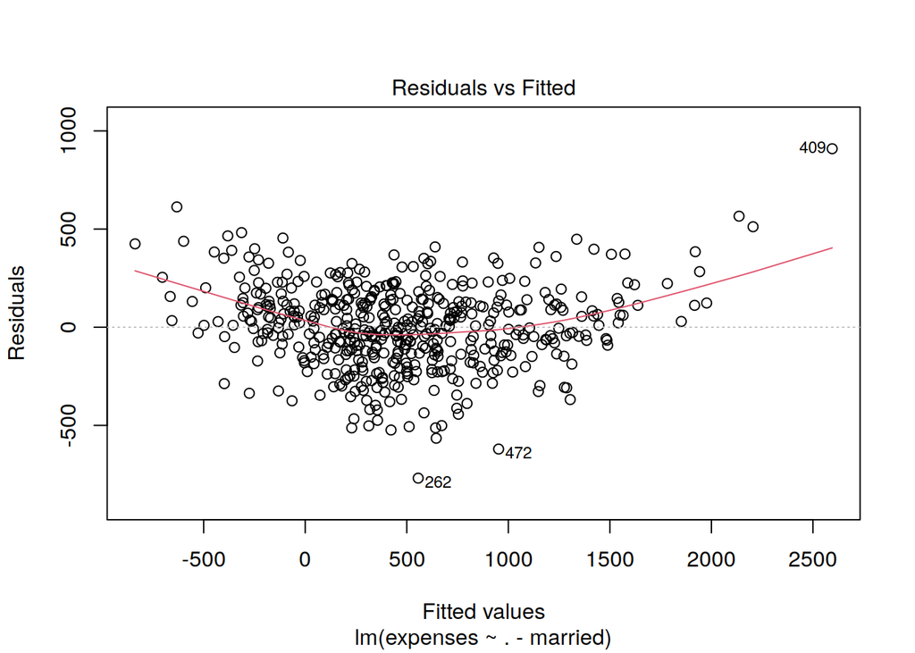

```r
plot(model.no.married, which=1)
```

Z powyższego wykresu wynika, że zależność między wydatkami a zmiennymi objaśniającymi nie jest do końca liniowa. Trudno zatem powiedzieć, że spełnione są założenia modelu liniowego.

Prawdopodobnie z tego powodu widzimy, że błędy nie są od siebie niezależne (różnica między sąsiednimi błędami jest mniejsza niż między błędami wybranymi losowo - autokorelacja).

## Rozkład residuów

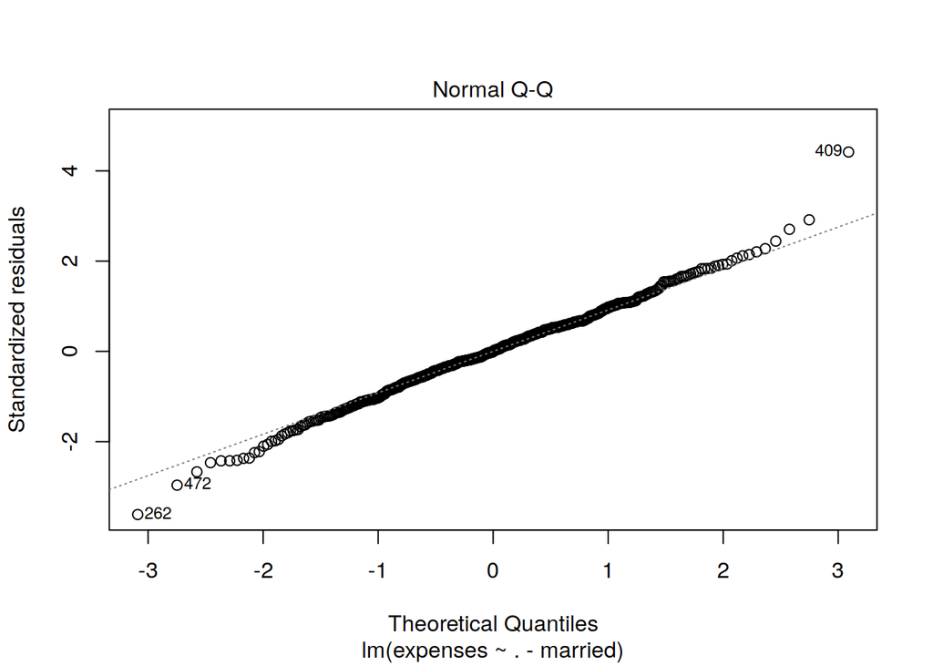

```r
plot(model.no.married, which=2)
```

Z powyższego wykresu wynika, że residua mają w przybliżeniu rozkład normalny.

## Homoskedatyczność wariancji

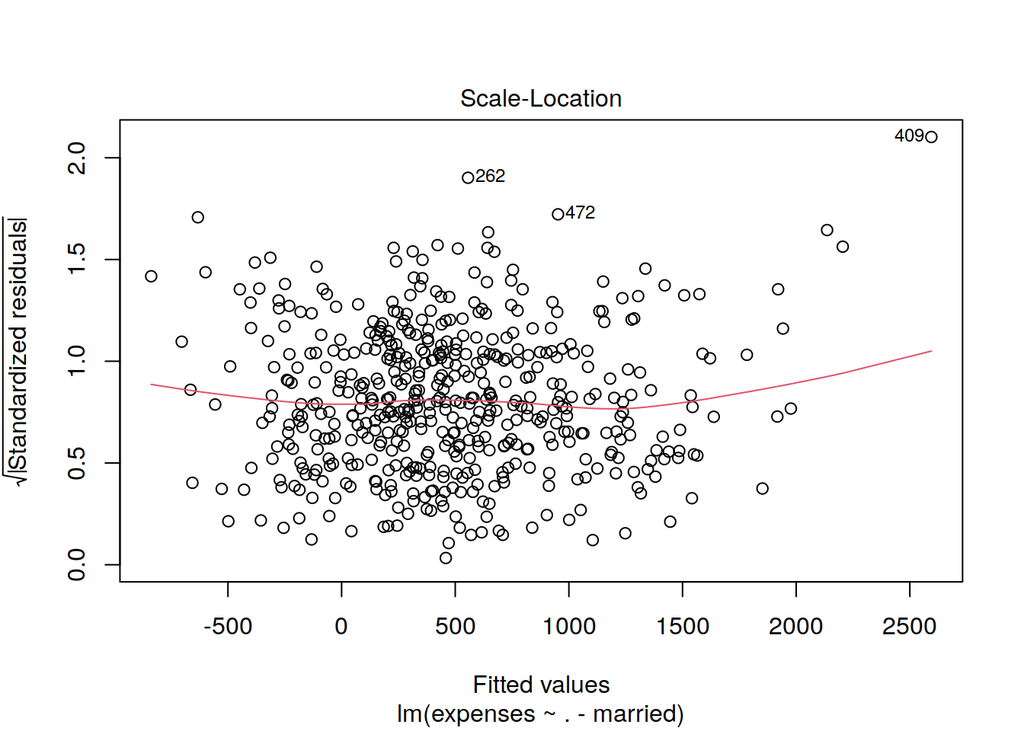

```r
plot(model.no.married, which=3)
```

Widzimy, że wariancja residuów raczej nie zależy od zmiennej objaśnianej - utrzymuje się na mniej więcej tym samym poziomie (Odchylenia czerwonej lini trendu od prostej może wynikać z małej liczby obserwacji po obu stronach osi X na wykresie).

# Obserwacje odstające

Poniżej widać wykres zależności błędów *standardyzowanych* od dźwigni.

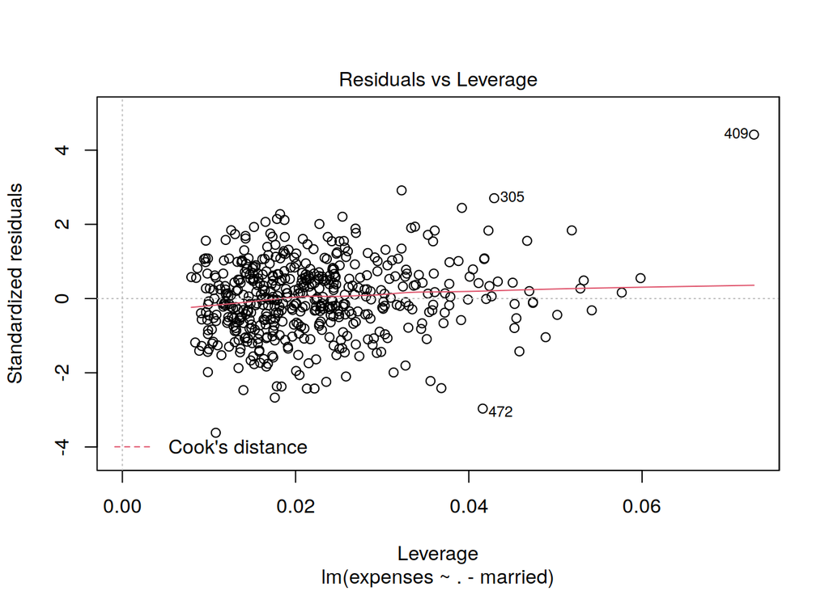

```r
plot(model.no.married, which=5)
```

A poniżej znajduje się wykres zależności błędów *studentyzowanych* w zależności od predykcji (Czerwone linie zaznaczają poziom $y=3$ i $y=-3$).

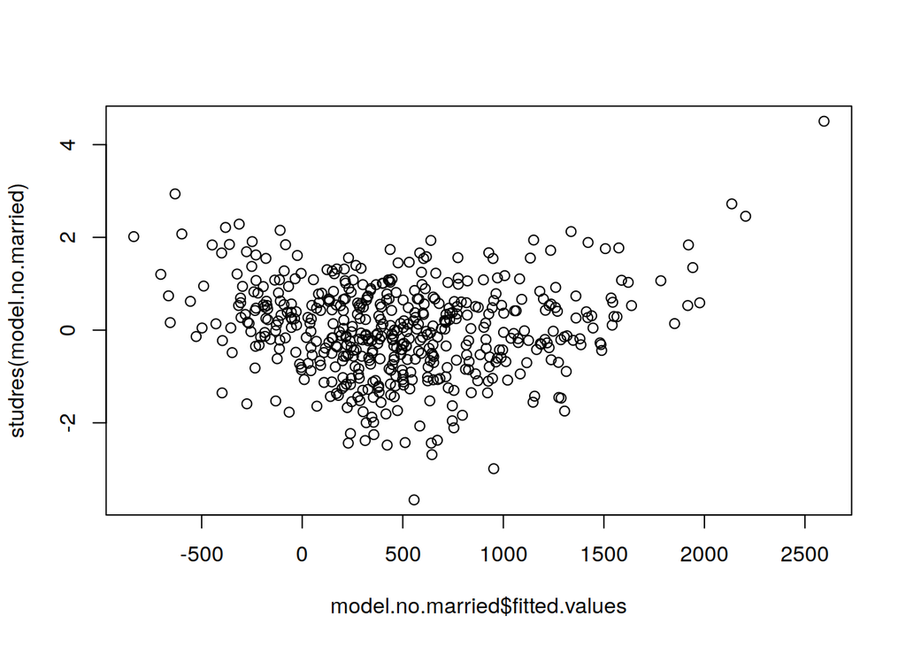

```r
plot(model.no.married$fitted.values, studres(model.no.married))
```

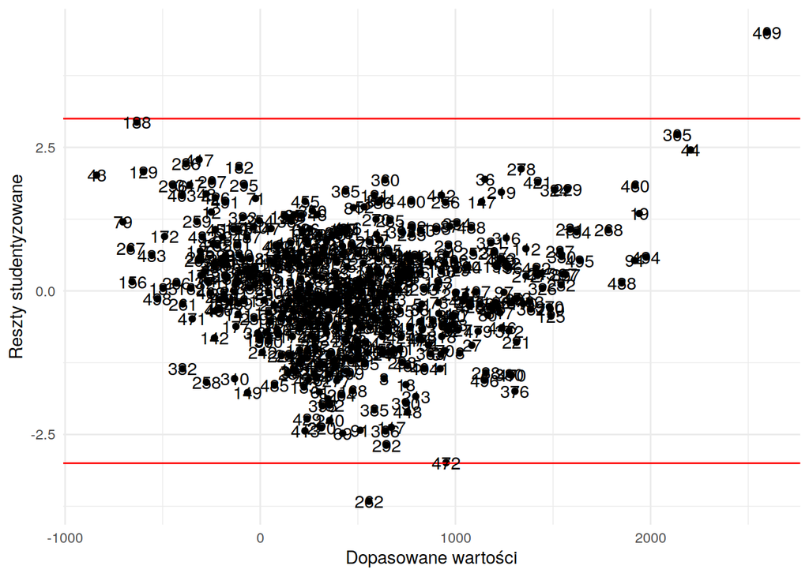

```r
studresd <- studres(model.no.married)
ggplot() + geom_point(aes(x=model.no.married$fitted.values, y=studresd)) + geom_hline(aes(yintercept=3), col='red') + geom_hline(aes(yintercept=-3), col='red') + geom_text(aes(x=model.no.married$fitted.values, y=studresd, label=seq(1, length(model.no.married$fitted.values), by=1))) + ylab("Reszty studentyzowane") + xlab("Dopasowane wartości") + theme_minimal()
```

Widzimy 3 obserwacje odstające (reszty studentyzowane odchylają się od 0 o więcej niż 3): 262, 409, 472.

Na wykładzie za dźwigniowe zostały uznane obserwacje, dla których dźwignia jest większa od $\frac{2(p+1)}{n}$. Sprawdźmy, czy istnieją obserwacje dźwigniowe wg tej definicji.

```r
p <- 10
n <- 500
which(hatvalues(model.no.married) > 2*(p+1)/n)
```

```
##   1  90 125 144 156 159 174 175 189 199 288 295 328 409 452 455 466 468
##   1  90 125 144 156 159 174 175 189 199 288 295 328 409 452 455 466 468
```

Widzimy, że jedyną obserwacją zarówno odstającą jak i dźwigniową jest 409. Możemy zatem zastanowić się nad usunięciem ze zbioru danych obserwacji 262 i 472 (obserwacji odstających, niedźwigniowych).